# Peer-graded Assignment: Statistical Inference Course Project

David Augusto

25/10/2020

#### The project consists of two parts:

1. A simulation exercise.
2. Basic inferential data analysis.

======================================================================================================================

#### Part 1: Simulation Exercise Instructions

In this project you will investigate the *exponential distribution* in R and compare it with the Central Limit Theorem.

The exponential distribution can be simulated in R with **rexp(n, lambda)** where:

1. **lambda** is the rate parameter.
2. The *mean* of exponential distribution is **1/lambda**.
3. the *standard deviation* is also **1/lambda**.

Set **lambda = 0.2** for all of the simulations.

*You will investigate the distribution of averages of 40 exponentials.*

Illustrate via simulation and associated explanatory text the properties of the distribution of the mean of 40 exponentials.

You should:

1. Show the **sample mean** and *compare it* to the **theoretical mean** of the distribution.
2. Show the **variance** and *compare it* to the **theoretical variance** of the distribution.
3. **Show that the distribution is approximately normal.**

======================================================================================================================

#### Exponential distribution:

The exponential distribution is defined by its cumulative distribution function

$$F(x) = 1-e^{-\lambda x}$$

The R function `rexp` generates random variables with an exponential distribution.

> Question 1 : Show the sample mean and compare it to the theoretical mean distribution

```r
set.seed(777)
n <- 40
Lambda <- 0.2
Simulations <- 1000
```

> Theoretical values:
1. Theoretical Mean is equal to: 5
2. Theoretical Standard Deviation is equal to: 0.7905694
3. Theoretical Variance is equal to: 0.625

```r
SampleMean <- 0

#For,this will create our n means from the rexp funtion.

for(i in 1:Simulations) {
  SampleMean <- c(SampleMean, mean(rexp(n, Lambda)))

}

mean(SampleMean)
```

```
## [1] 4.964824
```

> Question 2: Show the sample variance and compare it to the thoretical variance of the distribtution.

```r
Variance <- var(SampleMean)

Variance
```

```
## [1] 0.6625188
```

The sample variance is very close to the theoretical variance.

**Show that the distribution is aproximately normal**

This can be shown with 2 graph tools:

1. Histogram of the n means
2. The normal probability plot

======================================================================================================================

First we examine the Histogram,

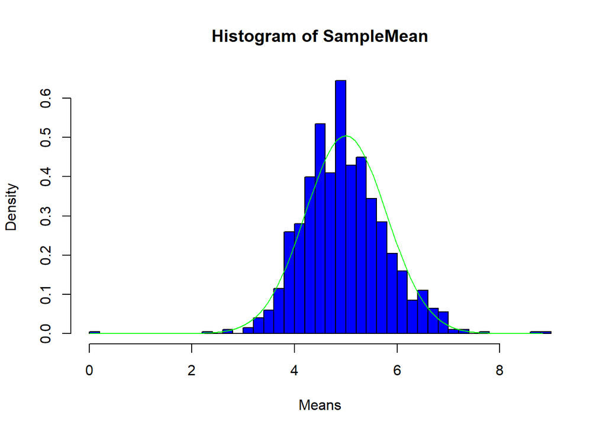

```r
hist(SampleMean, breaks = n, prob = T, col = "blue", xlab = "Means")
x <- seq(min(SampleMean), max(SampleMean), length = 100)
lines(x, dnorm(x, mean = 1/Lambda, sd = (1/Lambda/sqrt(n))), pch = 25, col = "green")
```

We conclude that the histogram appears to be bell shaped, and the mean is very close to the theoretical mean.

Then, for our Normal probability plot:

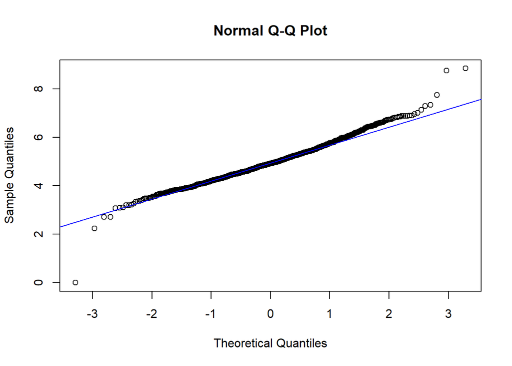

```r
qqnorm(SampleMean)
qqline(SampleMean, col = "blue")
```

The data should form an approximate straight line, in this case it appears almost linear, we can assume the data set **is approximately normally distributed**

======================================================================================================================

> Part 2: Basic Inferential Data Analysis Instructions
1. Load the ToothGrowth data and perform some basic exploratory data analyses

```r
library(ggplot2)
library(datasets)
data(ToothGrowth)
```

2. Provide a basic summary of the data.

```r
str(ToothGrowth)
```

```
## 'data.frame':    60 obs. of  3 variables:
##  $ len : num  4.2 11.5 7.3 5.8 6.4 10 11.2 11.2 5.2 7 ...
##  $ supp: Factor w/ 2 levels "OJ","VC": 2 2 2 2 2 2 2 2 2 2 ...
##  $ dose: num  0.5 0.5 0.5 0.5 0.5 0.5 0.5 0.5 0.5 0.5 ...
```

```r
summary(ToothGrowth)
```

```
##       len        supp         dose
##  Min.   : 4.20   OJ:30   Min.   :0.500
##  1st Qu.:13.07   VC:30   1st Qu.:0.500
##  Median :19.25           Median :1.000
##  Mean   :18.81           Mean   :1.167
##  3rd Qu.:25.27           3rd Qu.:2.000
##  Max.   :33.90           Max.   :2.000
```

======================================================================================================================

3. Use confidence intervals and/or hypothesis tests to compare tooth growth by supp and dose. (Only use the techniques from class, even if there’s other approaches worth considering)

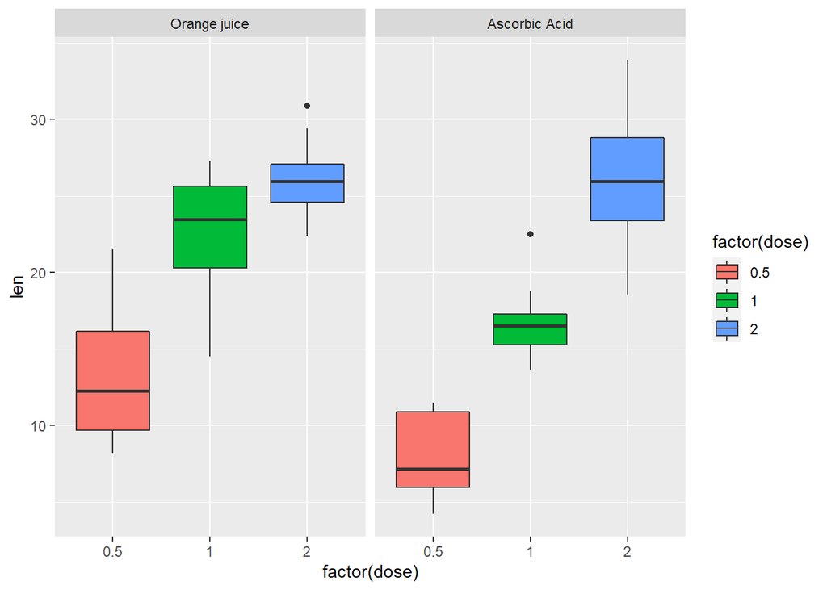

```r
ggplot(ToothGrowth, aes(factor(dose), len, fill = factor(dose))) +
      geom_boxplot() +
      facet_grid(.~supp, labeller = as_labeller(
            c("OJ" = "Orange juice",
              "VC" = "Ascorbic Acid")))
```

Next we propose different hypothesis test for the dataset:

====================================================================================================================== 1. First hypothesis test

Ho: mean growth of all the population of Orange Juice is == mean growth of all the population of Ascorbic acid

H1: mean growth of all the population of Orange Juice is =! mean growth of all the population of Ascorbic acid

```r
hyth1 <- t.test(len ~ supp, data = ToothGrowth)
hyth1$conf.int
```

```
## [1] -0.1710156  7.5710156
## attr(,"conf.level")
## [1] 0.95
```

```r
hyth1$p.value
```

```
## [1] 0.06063451
```

Since the p-value is 0.06063451 greater than 0.05. The null hypothesis **cannot** be rejected.

**We could assume that either one provides the same growth across dosage.**

======================================================================================================================

2. Second hypothesis test

Ho: mean growth of Orange Juice when the dose is .5 == mean growth of Ascorbic acid when the dose is .5

H1: mean growth of Orange Juice when the dose is .5 =! mean growth of Ascorbic acid when the dose is .5

```r
hyth2<-t.test(len ~ supp, data = subset(ToothGrowth, dose == 0.5))
hyth2$conf.int
```

```
## [1] 1.719057 8.780943
## attr(,"conf.level")
## [1] 0.95
```

```r
hyth2$p.value
```

```
## [1] 0.006358607
```

Since the p-value is 0.006358607 lower than 0.05. The null hypothesis **is** rejected.

**We could assume that the mean growth isn´t the same between supplements when the dose is 0.5**

======================================================================================================================

3. Third hypothesis test

Ho: mean growth of Orange Juice when the dose is 1 == mean growth of Ascorbic acid when the dose is 1

H1: mean growth of Orange Juice when the dose is 1 =! mean growth of Ascorbic acid when the dose is 1

```r
hyth3<-t.test(len ~ supp, data = subset(ToothGrowth, dose == 1))
hyth3$conf.int
```

```
## [1] 2.802148 9.057852
## attr(,"conf.level")
## [1] 0.95
```

```r
hyth3$p.value
```

```
## [1] 0.001038376
```

Since the p-value is 0.001038376 lower than 0.05. The null hypothesis **is** rejected.

**We could assume that the mean growth isn´t the same between supplements when the dose is 1**

======================================================================================================================

4. Fourth hypothesis test

Ho: mean growth of Orange Juice when the dose is 2 == mean growth of Ascorbic acid when the dose is 2

H1: mean growth of Orange Juice when the dose is 2 =! mean growth of Ascorbic acid when the dose is 2

```r
hyth4<-t.test(len ~ supp, data = subset(ToothGrowth, dose == 2))
hyth4$conf.int
```

```
## [1] -3.79807  3.63807
## attr(,"conf.level")
## [1] 0.95
```

```r
hyth4$p.value
```

```
## [1] 0.9638516
```

Since the p-value is 0.9638516 greater than 0.05. The null hypothesis **cannot** be rejected.

**We could assume that either one provides the same mean growth when the dose is 2.**

======================================================================================================================

> Conclusions

From the statistical analysis and the plotted data:

From the boxplot we can observe how the length behaves for each of the dosages:

- .05 and 1 the orange juice shows a greater length in comparison to the Ascorbic Acid.
- but for the dose 2, it appears as both OJ or AA have the approximately the same median, but bigger variance.

From this we can assume, when the dosage is smaller Orange juice tends to provide greater growth.

Now from the hypotesis testing we confirm what we saw in the boxplot

The mean is **not the same** when the dosage is .5 and 1,

And we **cannot reject that** the means are the same when the dosage is 2